# SVM Classifiers 18C 16x

Uriah Daugaard

4/29/2021

## Dependencies

```r
library(tidyverse)
library(randomForest)
library(readr)
library(viridis)
library(e1071)
library(caret)
```

## Data

### 16x

Note: there are only few individuals of the small ciliates because only cells bigger than 1000um2 are tracked at this magnification and most small ciliates (Tetrahymena, Dexiostoma and Loxocephalus) are smaller than that.

```r
load("../data/25x/Coleps_irchel/Morph_mvt.RData")
dd16 <- morph_mvt

load("../data/25x/Coleps_viridis/Morph_mvt.RData")
# dd16 <- rbind(dd16, morph_mvt)

load("../data/16x/Colpidium/Morph_mvt.RData")
morph_mvt$species <- "Colpidium"
dd16 <- rbind(dd16, morph_mvt)

# load("../data/16x/Didinium/Morph_mvt.RData")
# dd16 <- rbind(dd16, morph_mvt)

load("../data/16x/Euplotes/Morph_mvt.RData")
# morph_mvt <- morph_mvt %>% filter(mean_area>3000)
dd16 <- rbind(dd16, morph_mvt)

load("../data/16x/Euplotes_second/Morph_mvt.RData")
# morph_mvt <- morph_mvt %>% filter(mean_area>3000)
dd16 <- rbind(dd16, morph_mvt)

load("../data/16x/Paramecium_bursaria/Morph_mvt.RData")
dd16 <- rbind(dd16, morph_mvt)

load("../data/16x/Paramecium_caudatum/Morph_mvt.RData")
dd16 <- rbind(dd16, morph_mvt)

load("../data/16x/Stylonychia_1/Morph_mvt.RData")
morph_mvt$species <- "Stylonychia1"
dd16 <- rbind(dd16, morph_mvt)

load("../data/16x/Stylonychia_1_second/Morph_mvt.RData")
morph_mvt$species <- "Stylonychia1"
dd16 <- rbind(dd16, morph_mvt)

load("../data/16x/Stylonychia_2/Morph_mvt.RData")
morph_mvt$species <- "Stylonychia2"
dd16 <- rbind(dd16, morph_mvt)

load("../data/16x/Dexiostoma/Morph_mvt.RData")
dd16 <- rbind(dd16, morph_mvt)

load("../data/16x/Loxocephallus/Morph_mvt.RData")
dd16 <- rbind(dd16, morph_mvt)

load("../data/16x/Tetrahymena/Morph_mvt.RData")
morph_mvt$species <- "Tetrahymena"
dd16 <- rbind(dd16, morph_mvt)


## filtering

dd16 <- dd16 %>%
  filter(net_disp>50, net_speed>5)

dd16$magnification <- 1.6

table(dd16$species)
```

```
##
##       Coleps_irchel           Colpidium          Dexiostoma            Euplotes
##                 617                 341                  10                2028
##       Loxocephallus Paramecium_bursaria Paramecium_caudatum        Stylonychia1
##                   9                2652                2231                 650
##        Stylonychia2         Tetrahymena
##                 375                  25
```

```r
dd16$species <- ifelse(dd16$species %in% c("Tetrahymena","Dexiostoma","Loxocephallus"),"Smaller_ciliates",dd16$species)
```

## filtering out outliers

```r
dd16$id <- 1:nrow(dd16)
dd16 <- dd16 %>% na.omit()
dd16_long <- dd16 %>%
  dplyr::select(species, mean_area,sd_area,mean_perimeter,sd_perimeter,mean_major,
        sd_major,mean_ar,sd_ar,
        mean_turning,sd_turning,gross_disp,max_net,net_disp,net_speed,max_step,
        min_step,sd_step,sd_gross_speed,max_gross_speed,min_gross_speed, id) %>%
  pivot_longer(cols=-c(id,species), names_to="variable") %>%
  dplyr::group_by(variable,species) %>%
  mutate(iqr = IQR(value),
         first_quartile = quantile(value, probs = 0.25),
         third_quartile = quantile(value, probs = 0.75),
         outlier = ifelse(value<first_quartile-1.5*iqr | value>third_quartile+1.5*iqr,T,F))



outliers <- dd16_long %>%
  dplyr::filter(outlier==T) %>%
  dplyr::group_by(species, id) %>%
  dplyr::summarise(n = n()) %>%
  dplyr::filter(n>3)
table(outliers$species)
```

```
##
##       Coleps_irchel           Colpidium            Euplotes Paramecium_bursaria
##                  74                  12                  78                 237
## Paramecium_caudatum    Smaller_ciliates        Stylonychia1        Stylonychia2
##                  78                   8                  81                  24
```

```r
nrow(outliers)/nrow(dd16)
```

```
## [1] 0.06623406
```

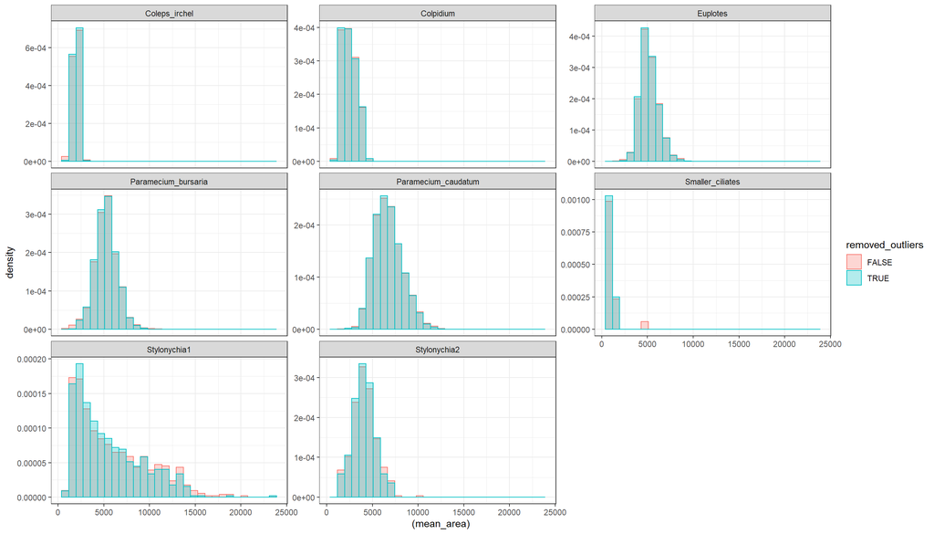

```r
dd16_filtered <- dd16 %>%
  dplyr::filter(!is.element(id,outliers$id))

dd16$removed_outliers <- F
dd16_filtered$removed_outliers <- T

dd16_comparison <- rbind(dd16,dd16_filtered)


dd16_comparison %>%
  ggplot(aes((mean_area), col=removed_outliers))+
  geom_histogram(aes(fill=removed_outliers, y=..density..), position = "identity", alpha=0.3) +
  # geom_boxplot(outlier.alpha = 0.3) +
  theme_bw() +
  facet_wrap(~species, scales = "free_y")
```

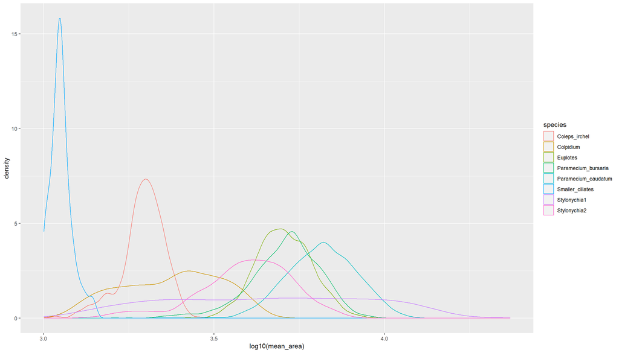

```r
dd16_filtered %>%
  ggplot(aes(log10(mean_area)))+
  geom_density(aes(col=species))
```

## Species compositions

```r
species <- unique(dd16$species)
compositions <- read_csv("../../compositions.csv")
comp_name <- compositions$composition
compositions$Smaller_ciliates <- with(compositions,
                                      ifelse(Tetrahymena == 1| Dexiostoma == 1| Loxocephallus == 1, 1, 0))

compositions <- compositions[,species]

compositions_list <- apply(compositions, 1, function(x){
  idx <- which(x==1)
  names(idx)
})

names(compositions_list) <- comp_name
```

## Classifiers

```r
classifier_plot_svm <- function(table, combination.nr){
  # cm <- classifier$confusion
  cm <- table
  ncol <- ncol(cm)
  cm <- apply(cm, 1, function(x) x/sum(x))

  cm_long <- data.frame(Predicted = factor(rep(rownames(cm),ncol), levels = rownames(cm)),
                        Truth = factor(rep(colnames(cm), each=ncol), levels = colnames(cm)),
                        Classification = as.vector(cm))

  plot <- cm_long %>%
    ggplot(aes(Predicted,Truth,fill=Classification))+
    geom_tile() +
    geom_text(aes(label = round(Classification, 3)), col="white") +
    scale_x_discrete(position = "top") +
    scale_y_discrete(limits = rev(levels(cm_long$Truth))) +
    scale_fill_viridis(option = "D", end=.8, discrete=FALSE)+
    theme(axis.text.x = element_text(angle = 90, hjust = 0))+
    theme(legend.text = element_text(size=14),
          axis.title = element_text(size=14),
          title = element_text(size=16),
          axis.text = element_text(size=13))+
    labs(title=paste("PPV of",combination.nr),fill="PPV")

  return(plot)
}


classifier_assessment_plot <- function(cf, combination.nr){

  cf.df <- cf$byClass[,1:4] %>%
    as.data.frame() %>%
    mutate(Species = gsub("Class: ", "", rownames(cf$byClass[,1:5]))) %>%
    rename("NPV" = "Neg Pred Value", "PPV" = "Pos Pred Value",
           "Sens" = "Sensitivity", "Spec" = "Specificity") %>%
    pivot_longer(cols = 1:4) %>%
    mutate(col = ifelse(value>=0.9,"1",
                        ifelse(value<0.9 & value>=0.8,"2",
                               ifelse(value<0.8 & value>=0.7,"3","4"))))

  plot <- cf.df %>%
    ggplot(aes(name,Species,fill=col))+
    geom_tile() +
    geom_text(aes(label = round(value, 3)), col="white") +
    scale_x_discrete(position = "top") +
    scale_y_discrete(limits = rev(levels(as.factor(cf.df$Species)))) +
    scale_fill_manual(values = c("#006837","#66bd63","#f46d43","#a50026"), breaks = c("1","2","3","4")) +
    theme(legend.text = element_text(size=14),
          title = element_text(size = 16),
          axis.title = element_blank(),
          axis.text = element_text(size=13),
          legend.position = "none")+
    labs(title=combination.nr, fill="")

  return(plot)
}
```

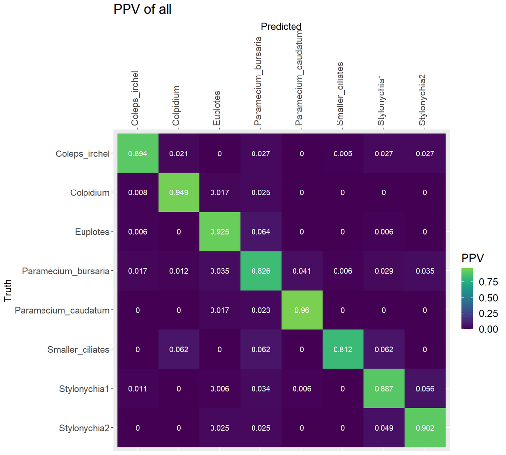

```r
formula <- factor(species) ~ mean_area + sd_area + mean_perimeter + sd_perimeter + mean_major +
        sd_major +  mean_ar + sd_ar +
        mean_turning + sd_turning + gross_disp + max_net + net_disp + net_speed + max_step +
        min_step + sd_step + sd_gross_speed + max_gross_speed + min_gross_speed

trainingdata <- dd16[complete.cases(dd16), ]

set.seed(624)

trainingdata$species <- factor(trainingdata$species)
split_up <- split(trainingdata, f = trainingdata$species)
subsamples <- lapply(split_up, function(x) {
  x %>% sample_n(ifelse(nrow(x) < 500, nrow(x), 500))})
trainingdata <- do.call("rbind", subsamples)
# table(sub_trainingdata$species)

# A stratified random split of the data
idx_train <- createDataPartition(trainingdata$species,
                                 p = 0.65, # percentage of data as training
                                 list = FALSE)

testdata <- trainingdata[-idx_train,]
trainingdata <- trainingdata[idx_train,]

obj <- tune(svm, formula, data = trainingdata, kernel="radial",
            ranges = list(gamma = 2^(-8:2), cost = 2^(1:10)), probability = TRUE,
            tunecontrol = tune.control(sampling = "fix", best.model = T))




cf <- caret::confusionMatrix(predict(obj$best.model, newdata=testdata %>% select(-species)),
                             testdata$species)

classifier_plot_svm(table = cf$table,
                    combination.nr = "all")
```

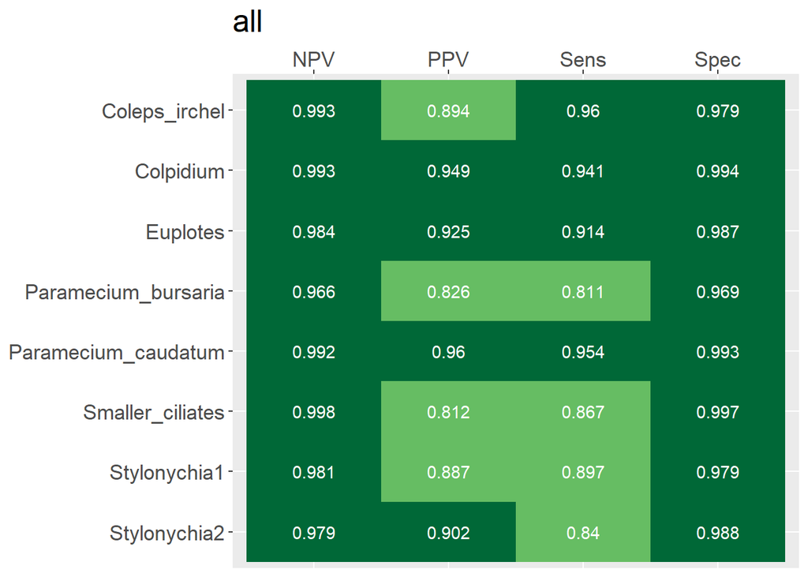

```r
classifier_assessment_plot(cf = cf, combination.nr = "all")
```

There are mainly 4 measures:

- Sensitivity: the probability that an individuals is classified as species X given that the it is of species X: P(Classified as species X | is of species X)
- Specificity: the probability that an individuals is not classified as species X given that it is not of species X: P(Not classified as species X | is not of species X)
- Positive Predictive Value PPV: the probability that an individual is of species X given that it has been classified as species X: P(is of species X | is classified as species X)
- Negative Predictive Value NPV: the probability that an individuals is not of species X given that it has not been classified as species X: P(is not of species X | has not been classified as species X)

PPV is the most important for us!

```r
formula <- factor(species) ~ mean_area + sd_area + mean_perimeter + sd_perimeter + mean_major +
        sd_major +  mean_ar + sd_ar +
        mean_turning + sd_turning + gross_disp + max_net + net_disp + net_speed + max_step +
        min_step + sd_step + sd_gross_speed + max_gross_speed + min_gross_speed

set.seed(62)
classifiers_18c_16x <- list()
classifiers_18c_16x_plots <- list()
classifiers_18c_16x_assess_plots <- list()

trainingdata <- dd16_filtered[complete.cases(dd16_filtered), ]

for(i in 1:length(compositions_list)){
  sub_trainingdata <- trainingdata %>%
    filter(species %in% c(compositions_list[[i]]))
  n.var <- length(unique(sub_trainingdata$species))
  sub_trainingdata$species <- factor(sub_trainingdata$species)

  split_up <- split(sub_trainingdata, f = sub_trainingdata$species)
  subsamples <- lapply(split_up, function(x) {
    x %>% sample_n(ifelse(nrow(x) < 500, nrow(x), 500))})
  sub_trainingdata <- do.call("rbind", subsamples)
  # table(sub_trainingdata$species)
  # A stratified random split of the data
  idx_train <- createDataPartition(sub_trainingdata$species,
                                   p = 0.7, # percentage of data as training
                                   list = FALSE)

  sub_testdata <- sub_trainingdata[-idx_train,]
  sub_trainingdata <- sub_trainingdata[idx_train,]

  n.min <- min(table(sub_trainingdata$species))

  obj <- tune(svm, formula, data = sub_trainingdata, kernel="radial",
            ranges = list(gamma = 2^(-8:2), cost = 2^(1:10)), probability = TRUE,
            tunecontrol = tune.control(sampling = "fix", best.model = T))

  classifiers_18c_16x[[i]] <- obj$best.model

  cf <- caret::confusionMatrix(predict(obj$best.model, newdata=sub_testdata %>% select(-species)),
                       sub_testdata$species)

  classifiers_18c_16x_plots[[i]] <- classifier_plot_svm(table = cf$table,
                                                        combination.nr = names(compositions_list)[[i]])

  classifiers_18c_16x_assess_plots[[i]] <- classifier_assessment_plot(cf, names(compositions_list)[[i]])
}

names(classifiers_18c_16x_plots) <- names(classifiers_18c_16x) <-
  names(classifiers_18c_16x_assess_plots) <- comp_name
```

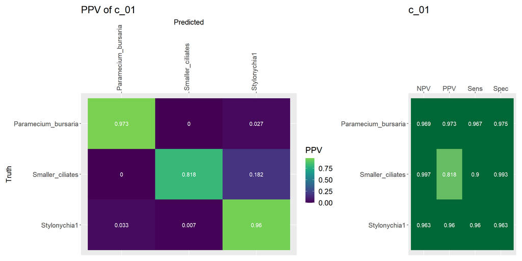

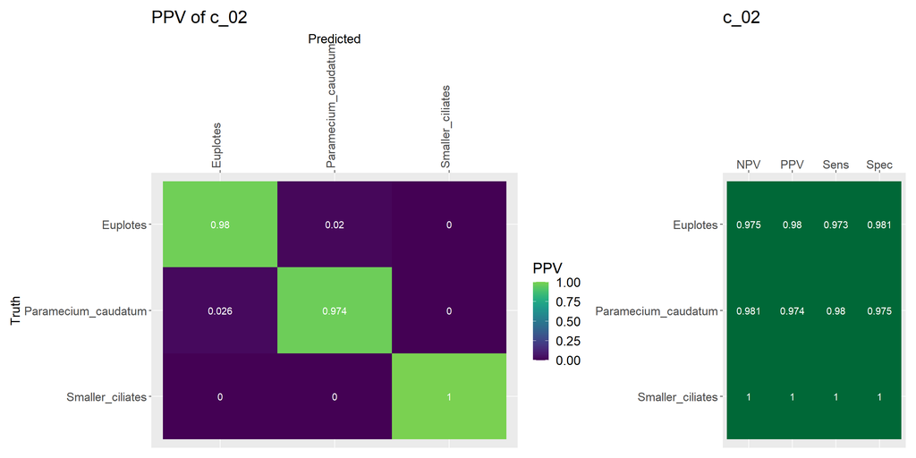

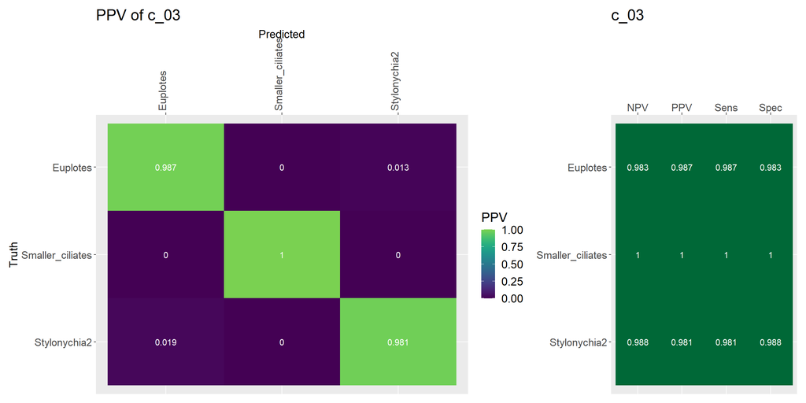

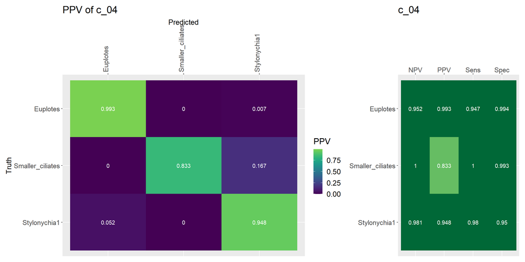

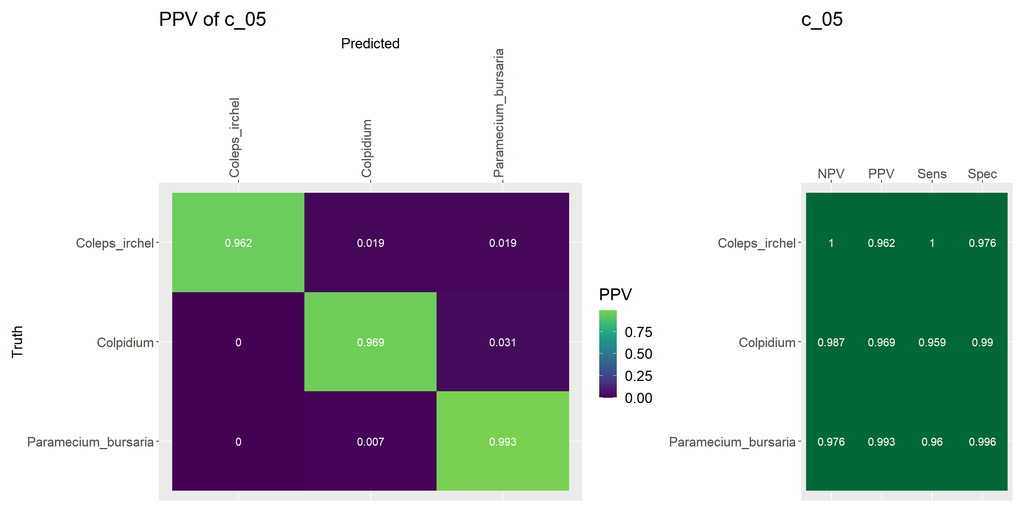

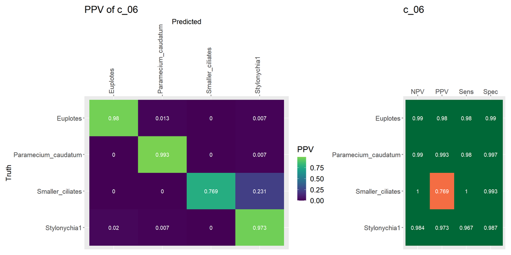

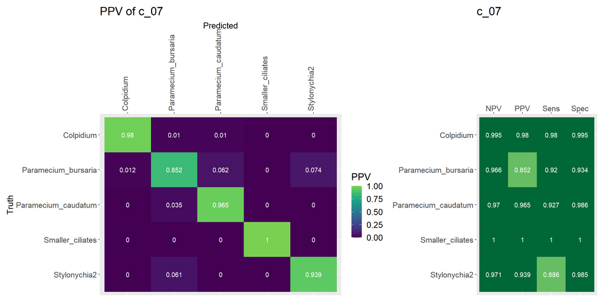

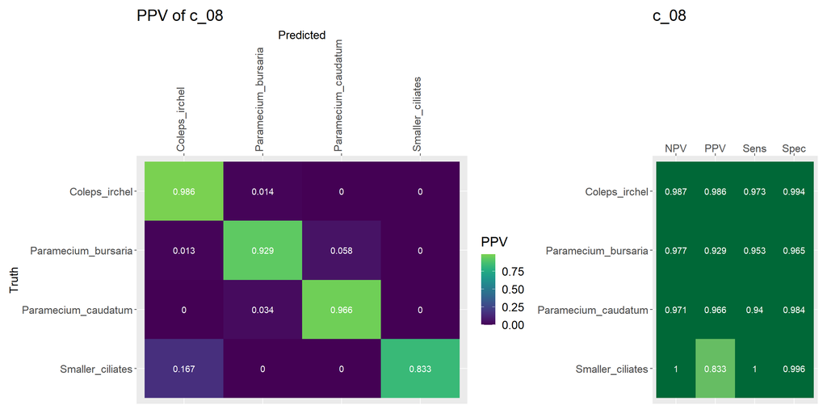

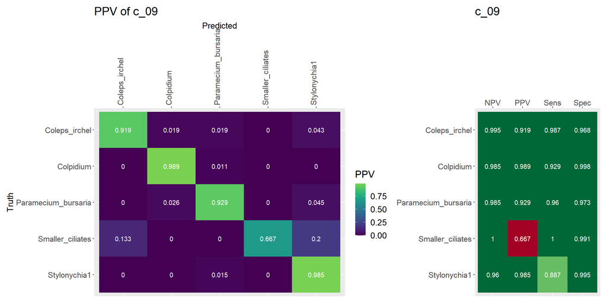

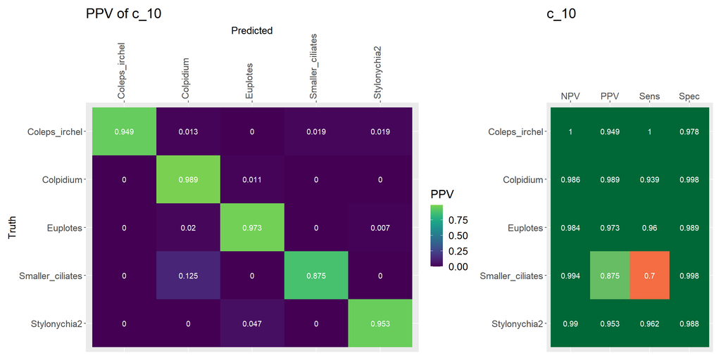

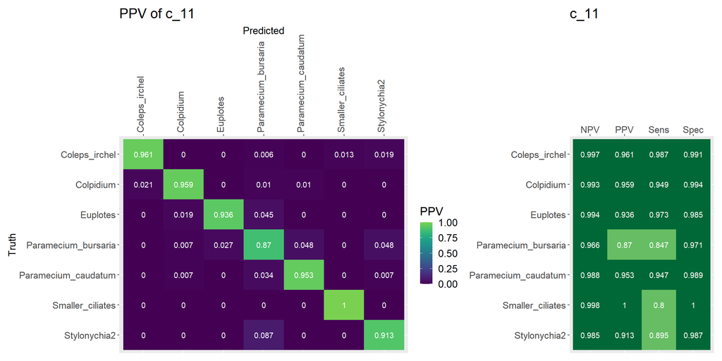

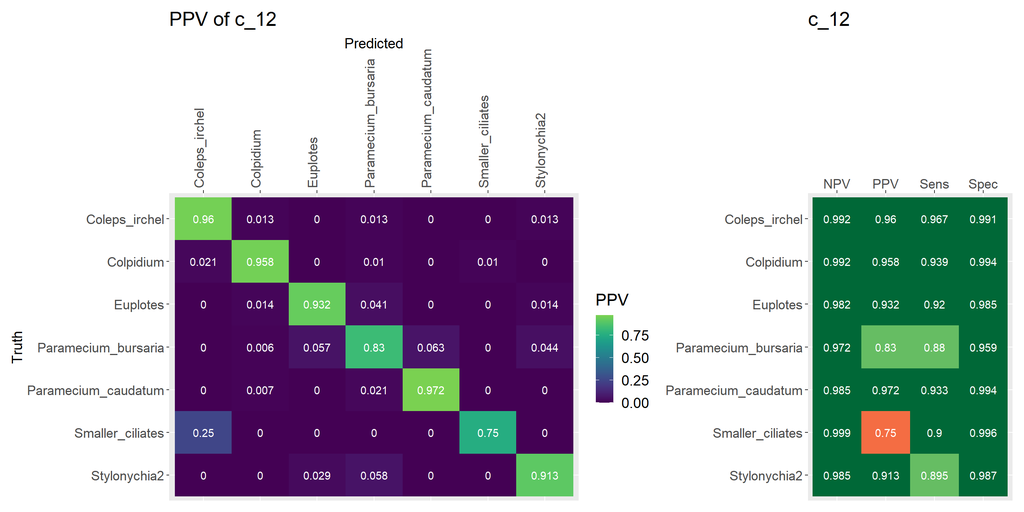

[3 more figures not shown]

```r
library(patchwork)
for(i in 1:length(classifiers_18c_16x_plots)){
  print(classifiers_18c_16x_plots[[i]] + classifiers_18c_16x_assess_plots[[i]] +
    plot_layout(widths = c(4,2)))
}
```

## Save classifiers

```r
saveRDS(classifiers_18c_16x, "svm_video_classifiers_18c_16x_trained_december2021.rds")
# cl <- readRDS("classifiers_18c_16x.rds")
```